# Población NINI

Autores: Rubén Alfredo Llosa Chaqui, Yhilda Mirella Gil Chavez, Jose Antonio Achancaray Ramirez y Patricia Janeth Bendezú Santana

18 de enero de 2025

# Introducción

## Problemática

El país está atravesando por un periodo favorable para el crecimiento y desarrollo económico debido a la existencia de una parte importante de su población en edad de trabajar. Los beneficios de este periodo no son automáticos, requieren inversiones en educación y en empleo, especialmente en los jóvenes. Dado que estos constituyen una fuente importante para capitalizar esta ventana de oportunidades, resulta crucial estudiar a aquellos que están excluidos del ámbito educativo y laboral, es decir, los que conforman la población que ni estudia ni trabaja (NINI). En este sentido, el objetivo de este trabajo es caracterizar a esta población, así como identificar los determinantes sociales que influyen en la probabilidad de pertenecer a esta población.

## Planteamiento de problema

¿Cuáles son las características de la población NINI? ¿Cuáles son los determinantes de la población NINI?

# 1. Base de datos

## 1.1. Cargar bases de datos

Se limpia la consola de trabajo

```r
rm(list=ls())
```

Se instala librerias

```r
if (!require("haven")) install.packages("haven")
if (!require("tidyverse")) install.packages("tidyverse")
if (!require("foreign")) install.packages("foreign")
if (!require("survey")) install.packages("survey")
if (!require("ggplot2")) install.packages("ggplot2")
if (!requireNamespace("kableExtra", quietly = TRUE)) install.packages("kableExtra")
if (!require("MASS")) install.packages("MASS")
if (!require("pROC")) install.packages("pROC")
```

Se activa las librerias

```r
library(dplyr)
library(stringr)
library(knitr)
library(haven)
library(survey)
library(ggplot2)
library(kableExtra)
library(MASS)
library(pROC)
```

Se configura la carpeta directorio

```r
ruta <- "C:/Users/M S I/OneDrive/ymgc/notebook/r/pa_grupo3/"
setwd(ruta)
getwd()
```

```
## [1] "C:/Users/M S I/OneDrive/ymgc/notebook/r/pa_grupo3"
```

Se importa 3 módulos de las ENAHO: Empleo, Educación y Miembros de hogar

```r
m_empleo <- read_dta(paste("./enaho01a-2023-500.dta",sep="/"))
m_educacion <- read_dta(paste("./enaho01a-2023-300.dta",sep="/"))
m_miembros <- read_dta(paste("./enaho01-2023-200.dta",sep="/"))
```

## 1.2. Unir base de datos

Se combina los módulos por las variables llave (conglome, vivienda, hogar, codperso)

```r
datos <- left_join(m_empleo, m_educacion, by = c("conglome", "vivienda", "hogar", "codperso"))
datos <- left_join(datos, m_miembros, by = c("conglome", "vivienda", "hogar", "codperso"))
```

## 1.3. Crear variables

- **Seleccionar las personas que tienen 15 a 29 años de edad**

Se renombra la variable p208a a “edad”

```r
datos <- datos %>% rename(edad =p208a)
table(datos$edad, useNA = "alw")
```

```
##
##   14   15   16   17   18   19   20   21   22   23   24   25   26   27   28   29
## 2306 2293 2146 2116 2101 1811 1725 1527 1444 1432 1360 1346 1338 1388 1437 1373
##   30   31   32   33   34   35   36   37   38   39   40   41   42   43   44   45
## 1391 1441 1397 1371 1428 1479 1434 1400 1499 1427 1474 1376 1447 1455 1383 1433
##   46   47   48   49   50   51   52   53   54   55   56   57   58   59   60   61
## 1426 1413 1355 1313 1393 1348 1332 1306 1263 1187 1218 1209 1229 1087 1169 1039
##   62   63   64   65   66   67   68   69   70   71   72   73   74   75   76   77
## 1076 1011  976  909  885  849  882  748  793  647  733  663  610  547  522  494
##   78   79   80   81   82   83   84   85   86   87   88   89   90   91   92   93
##  515  393  396  380  331  296  260  236  203  210  172  139  130   85   73   60
##   94   95   96   97   98 <NA>
##   45   38   24   16   42    0
```

Se filtra para jóvenes entre 15-29 años

```r
jovenes <- datos %>% filter(edad >= 15 & edad <= 29)
table(jovenes$edad, useNA = "alw")
```

```
##
##   15   16   17   18   19   20   21   22   23   24   25   26   27   28   29 <NA>
## 2293 2146 2116 2101 1811 1725 1527 1444 1432 1360 1346 1338 1388 1437 1373    0
```

Se libera la memoria

```r
rm(datos, m_educacion, m_empleo, m_miembros)
```

### Variable residencia

Se genera la tabla de frecuencia en función a la variable p204 - ¿Es miembro del hogar?

```r
table(jovenes$p204, useNA = "alw")
```

```
##
##     1     2  <NA>
## 24642   195     0
```

Se genera la tabla de frecuencia en función a la variable p205 - ¿Se encuentra ausente del hogar 30 dias a mas?

```r
table(jovenes$p205, useNA = "alw")
```

```
##
##     1     2  <NA>
##   892 23750   195
```

Se genera la tabla de frecuencia en función a la variable p206 - ¿Esta presente en el hogar 30 dias a mas?

```r
table(jovenes$p206, useNA = "alw")
```

```
##
##     1  <NA>
##   195 24642
```

Se crea la variable “residencia” usando una condición logica y se muestra la tabla de frecuencia

```r
jovenes <- jovenes %>% mutate(residencia = ifelse((p204 == 1 & p205 == 2) | (p204 == 2 & p206 == 1), 1, 0))
table(jovenes$residencia, useNA = "alw")
```

```
##
##     0     1  <NA>
##   892 23945     0
```

Se filtra el dataframe donde residencia = 1 y se muestra la tabla de frecuencia

```r
jovenes <- jovenes %>% filter(residencia == 1)
table(jovenes$residencia, useNA = "alw")
```

```
##
##     1  <NA>
## 23945     0
```

### Variable departamento

Se crea una nueva columna llamada departamento con los dos primeros caracteres del ubigeo. Se emplea mutate() para recodificar los numeros en nombres de departamentos. Se muestra la tabla de frecuencia de la variable departamento.

```r
jovenes$departamento <- as.numeric(substr(jovenes$ubigeo, 1, 2))
jovenes <- jovenes %>% mutate(departamento = recode(departamento, '1' = "Amazonas", '2' = "Ancash", '3' = "Apurímac",
                                                    '4' = "Arequipa", '5' = "Ayacucho", '6' = "Cajamarca", '7' = "Callao",
                                                    '8' = "Cusco", '9' = "Huancavelica", '10' = "Huánuco", '11' = "Ica",
                                                    '12' = "Junín", '13' = "La Libertad", '14' = "Lambayeque", '15' = "Lima",
                                                    '16' = "Loreto", '17' = "Madre de Dios", '18' = "Moquegua",
                                                    '19' = "Pasco", '20' = "Piura", '21' = "Puno", '22' = "San Martín",
                                                    '23' = "Tacna", '24' = "Tumbes", '25' = "Ucayali"))
table(jovenes$departamento, useNA = "alw")
```

```
##
##      Amazonas        Ancash      Apurímac      Arequipa      Ayacucho
##           816           960           523          1108           670
##     Cajamarca        Callao         Cusco  Huancavelica       Huánuco
##           824           834           792           635           818
##           Ica         Junín   La Libertad    Lambayeque          Lima
##          1099          1004          1155          1132          3305
##        Loreto Madre de Dios      Moquegua         Pasco         Piura
##          1230           431           539           603          1365
##          Puno    San Martín         Tacna        Tumbes       Ucayali
##           661           990           873           607           971
##          <NA>
##             0
```

### Variable área de residencia

Se verifica la distribución de la variable “estrato” incluyendo los valores perdidos (NA).

```r
table(jovenes$estrato, useNA = "alw")
```

```
##
##    1    2    3    4    5    6    7    8 <NA>
## 4621 5171 2120 1938 3017 1032 4434 1612    0
```

Se procedio a recodificar la variable “area” con los valores (Urbano, Rural, NA) y verificamos la distribución de la variable.

```r
jovenes <- jovenes %>% mutate( area = ifelse(estrato>=1 & estrato<=5, "Urbano", ifelse(estrato>=6 & estrato<=8, "Rural", NA )))
table(jovenes$area, useNA = "alw")
```

```
##
##  Rural Urbano   <NA>
##   7078  16867      0
```

### Variable sexo

Se verifica la distribución de la variable “p207” incluyendo los valores perdidos (NA).

```r
table(jovenes$p207, useNA = "alw")
```

```
##
##     1     2  <NA>
## 12217 11728     0
```

Se procedio a recodificar la variable “sexo” con los valores (Hombre, Mujer, NA) y verificamos la distribución de la variable.

```r
jovenes <- jovenes %>% mutate(sexo = ifelse(p207==1, "Hombre", ifelse(p207==2, "Mujer", NA)))
table(jovenes$sexo, useNA = "alw")
```

```
##
## Hombre  Mujer   <NA>
##  12217  11728      0
```

### Variable region natural

Se verifica la distribución de la variable “dominio” incluyendo los valores perdidos (NA).

```r
table(jovenes$dominio, useNA = "alw")
```

```
##
##    1    2    3    4    5    6    7    8 <NA>
## 3895 2419 1566 1273 3471 2821 5370 3130    0
```

Se recodifica la variable “region” con los valores (Costa, Sierra, Selva, NA) y verificamos la distribución de la variable.

```r
jovenes <- jovenes %>% mutate(region = ifelse( (dominio>=1 & dominio<=3) | dominio==8, "Costa",
                                               ifelse(dominio>=4 & dominio<=6, "Sierra",
                                               ifelse(dominio==7, "Selva", NA))))
table(jovenes$region, useNA = "alw")
```

```
##
##  Costa  Selva Sierra   <NA>
##  11010   5370   7565      0
```

### Variable grupo de edad

Se verifica la distribución de la variable “edad” incluyendo los valores perdidos (NA).

```r
table(jovenes$edad, useNA = "alw")
```

```
##
##   15   16   17   18   19   20   21   22   23   24   25   26   27   28   29 <NA>
## 2266 2090 2010 2003 1709 1625 1422 1381 1365 1325 1309 1308 1364 1415 1353    0
```

Se recodifica la variable “edad” con los valores (De 15 a 17 años, De 18 a 24 años, De 25 a 29 años, NA) y verificamos la distribución de la variable.

```r
jovenes <- jovenes %>% mutate(gedad = case_when( edad %in% c(15:17) ~ "De 15 a 17 años",
                                                 edad %in% c(18:24) ~ "De 18 a 24 años",
                                                 edad %in% c(25:29) ~ "De 25 a 29 años"))
table(jovenes$gedad, useNA = "alw")
```

```
##
## De 15 a 17 años De 18 a 24 años De 25 a 29 años            <NA>
##            6366           10830            6749               0
```

### Variable nivel educativo

Se verifica la distribución de la variable “p301a.x” incluyendo los valores perdidos (NA).

```r
table(jovenes$p301a.x, useNA = "alw")
```

```
##
##    1    2    3    4    5    6    7    8    9   10   11   12 <NA>
##  126    6  466  824 6304 7792 1863 1426 3367 1612   87   43   29
```

Se recodifica la variable “p301a.x” con los valores (Primaria, Secundaria, SNU, SU, NA) y verificamos la distribución de la variable.

```r
jovenes <- jovenes %>% mutate(nivel_educ = ifelse( (p301a.x>=1 & p301a.x<=4) | p301a.x==12, "Primaria",
                                           ifelse( (p301a.x>=5 & p301a.x<=6), "Secundaria",
                                           ifelse( (p301a.x>=7 & p301a.x<=8), "SNU",
                                           ifelse( (p301a.x>=9 & p301a.x<=11), "SU", NA)))))
table(jovenes$nivel_educ, useNA = "alw")
```

```
##
##   Primaria Secundaria        SNU         SU       <NA>
##       1465      14096       3289       5066         29
```

### Variable lengua materna

Se verifica la distribución de la variable “p300a” incluyendo los valores perdidos (NA).

```r
table(jovenes$p300a, useNA = "alw")
```

```
##
##     1     2     3     4     6     7     8     9    10    11    12    13    14
##  2067   215   107 21054    34     2    58    14   116   148    46    26     9
##    15  <NA>
##    20    29
```

Se recodifica la variable “lengua” con los valores (Castellano, Lengua Nativa, NA) y verificamos la distribución de la variable.

```r
jovenes <- jovenes %>% mutate(lengua = ifelse(p300a==4, "Castellano", "Lengua nativa"))
table(jovenes$lengua, useNA = "alw")
```

```
##
##    Castellano Lengua nativa          <NA>
##         21054          2862            29
```

### Variable nini

Se verifica la distribución de la variable “ocu500” incluyendo los valores perdidos (NA).

```r
table(jovenes$ocu500, useNA = "alw")
```

```
##
##     0     1     2     3     4  <NA>
##    51 13194  1176   338  9186     0
```

Se verifica la distribución de la variable “p307” incluyendo los valores perdidos (NA).

```r
table(jovenes$p307, useNA = "alw")
```

```
##
##     1     2  <NA>
##  8375   974 14596
```

Se recodifica la variable “p307”, aplicando la condicional, si tiene un valor NA reemplazalo con 2 y verificamos la distribución de la variable.

```r
jovenes <- jovenes %>% mutate(p307 = ifelse(is.na(p307), 2, p307))
table(jovenes$p307, useNA = "alw")
```

```
##
##     1     2  <NA>
##  8375 15570     0
```

Se recodifica la variable “nini”, que identifica jóvenes que no estudian ni trabajan y verificamos la distribución de la variable.

```r
jovenes <- jovenes %>% mutate(nini = ifelse( (ocu500==3 | ocu500==4) & (p307==2), 1, 0))
table(jovenes$nini, useNA = "alw")
```

```
##
##     0     1  <NA>
## 19497  4448     0
```

## 1.4. Seleccionar variables

Seleccionamos especificamente las columnas trabajadas del dataframe “jovenes”.

```r
jovenes <- jovenes %>% dplyr::select(departamento, area, sexo, region, gedad, nivel_educ, lengua, nini, conglome, estrato, fac500a)
```

## 1.5. Guardar base de datos limpia

Se guarda el dataframe “jovenes” filtrado.

```r
save(jovenes, file=paste("./joevenes15a29.RData",sep="/"))
```

# 2. Población NINI

## 2.1. Especificar el tipo de muestreo

Se carga la base de datos limpia

```r
load(paste("./joevenes15a29.RData",sep="/"))
```

Se especifica el tipo de muestreo

```r
encuesta = svydesign(data=jovenes, id=~conglome, strata=~estrato, weights=~fac500a)
```

## 2.2. Población NINI

En el año 2023, se estima que el 19.02% de la población de 15 a 29 años de edad, ni estudia ni trabaja (NINI).

```r
nini <- svymean(~nini, encuesta, deff=F, na.rm=T)
nini
```

```
##        mean    SE
## nini 0.1902 0.004
```

# 3. Población NINI: características

La población conformada por adolescentes y jóvenes entre 15 y 29 años de edad que ni estudia ni trabaja, también conocida como Nini, hace referencia al sector de la población que no asiste a algún centro educativo estando desocupado o comprendido en la población económicamente no activa (No PEA).

## 3.1. NINI según departamento

Según los datos por departamento, en el año 2023, en Loreto (25.19%) se presentó el mayor porcentaje de población que ni estudia ni trabaja (nini), le sigue Tumbes con el 24.99% y Madre de Dios con 22.33%.

```r
nini_dpto <- svyby(~nini, ~departamento, encuesta, svymean, deff=F, na.rm=T)
nini_dpto <- nini_dpto %>% mutate(across(where(is.numeric), ~ round(. * 100, 2)),
                                  cv = round((se/nini)*100,2))
kable(nini_dpto, digits = 2, row.names = FALSE,
      col.names = c("Departamento", "Proporción Nini", "Error estándar", "Coeficiente de variación (%)"))
```

| Departamento | Proporción Nini | Error estándar | Coeficiente de variación (%) |
| --- | --- | --- | --- |
| Amazonas | 17.15 | 1.76 | 10.26 |
| Ancash | 15.97 | 1.31 | 8.20 |
| Apurímac | 9.70 | 1.34 | 13.81 |
| Arequipa | 20.47 | 2.10 | 10.26 |
| Ayacucho | 16.68 | 1.82 | 10.91 |
| Cajamarca | 21.03 | 1.86 | 8.84 |
| Callao | 19.55 | 1.70 | 8.70 |
| Cusco | 16.73 | 1.60 | 9.56 |
| Huancavelica | 8.85 | 1.45 | 16.38 |
| Huánuco | 16.76 | 1.89 | 11.28 |
| Ica | 14.85 | 1.29 | 8.69 |
| Junín | 15.74 | 1.40 | 8.89 |
| La Libertad | 20.24 | 1.36 | 6.72 |
| Lambayeque | 21.07 | 1.45 | 6.88 |
| Lima | 20.39 | 0.92 | 4.51 |
| Loreto | 25.19 | 1.52 | 6.03 |
| Madre de Dios | 22.33 | 3.11 | 13.93 |
| Moquegua | 19.57 | 2.33 | 11.91 |
| Pasco | 13.18 | 1.74 | 13.20 |
| Piura | 18.79 | 1.42 | 7.56 |
| Puno | 17.44 | 1.85 | 10.61 |
| San Martín | 18.90 | 1.87 | 9.89 |
| Tacna | 19.53 | 2.68 | 13.72 |
| Tumbes | 24.99 | 2.21 | 8.84 |
| Ucayali | 15.30 | 1.32 | 8.63 |

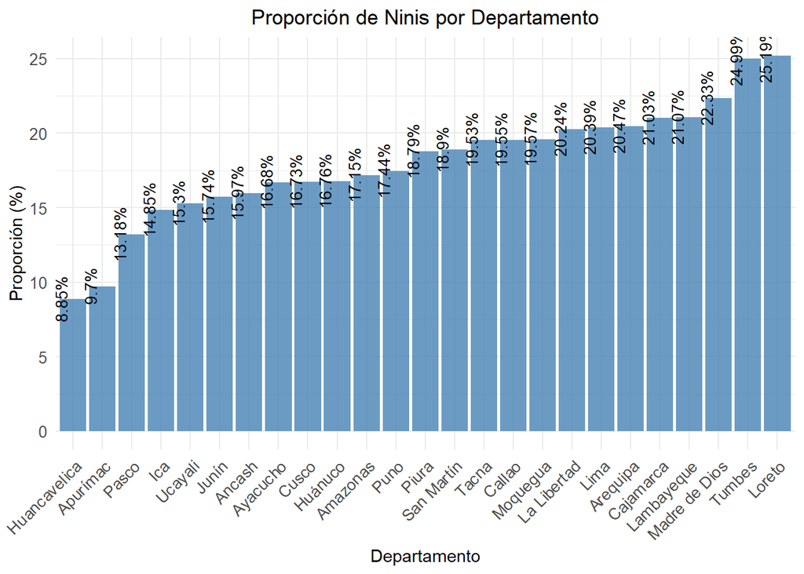

```r
# Gráfico de barras de Ninis por Departamento
ggplot(nini_dpto, aes(x = reorder(departamento, nini), y = nini)) +
  geom_bar(stat = "identity", fill = "steelblue", alpha = 0.8) +
  geom_text(aes(label = paste0(round(nini, 2), "%")),
            vjust = -0.5, angle = 90, size = 3.5, color = "black") +
  labs(
    title = "Proporción de Ninis por Departamento",
    x = "Departamento",
    y = "Proporción (%)"
  ) +
  theme_minimal() +
  theme(
    axis.text.x = element_text(angle = 45, hjust = 1),
    plot.title = element_text(hjust = 0.5),
    axis.text = element_text(size = 10)
  )
```

## 3.2. NINI según área de residencia

Se estimó que el 19.02% de la población es nini. Este problema afectó en mayor proporción a los jóvenes del área urbana (19.56%) que del área rural (16.63%).

```r
nini_area <- svyby(~nini, ~area, encuesta, svymean, deff=F, na.rm=T)
nini_area <- nini_area %>% mutate(across(where(is.numeric), ~ round(. * 100, 2)),
                                  cv = round((se/nini)*100,2))
kable(nini_area, digits = 2, row.names = FALSE, col.names = c("Área de residencia", "Proporción Nini", "Error estándar", "Coeficiente de variación (%)"))
```

| Área de residencia | Proporción Nini | Error estándar | Coeficiente de variación (%) |
| --- | --- | --- | --- |
| Rural | 16.63 | 0.58 | 3.49 |
| Urbano | 19.56 | 0.48 | 2.45 |

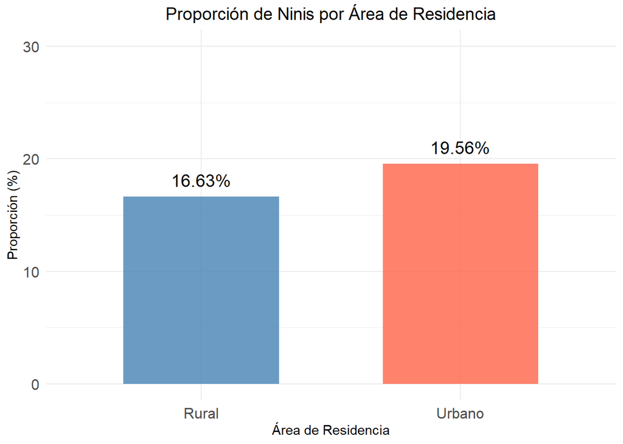

```r
#Grafico de barras de Ninis por Area de Residencia
ggplot(nini_area, aes(x = area, y = nini, fill = area)) +
  geom_bar(stat = "identity", width = 0.6, alpha = 0.8) +
  geom_text(aes(label = paste0(round(nini, 2), "%")),
            vjust = -0.8, size = 5, color = "black") +
  scale_fill_manual(values = c("steelblue", "tomato")) +
  labs(
    title = "Proporción de Ninis por Área de Residencia",
    x = "Área de Residencia",
    y = "Proporción (%)",
    fill = "Área"
  ) +
  ylim(0, 30) + # Amplía el rango del eje Y
  theme_minimal() +
  theme(
    axis.text.x = element_text(size = 12),
    axis.text.y = element_text(size = 12),
    plot.title = element_text(hjust = 0.5, size = 14),
    legend.position = "none"
  )
```

## 3.3. NINI según sexo

En la encuesta, se observa que existe una marcada diferencia por sexo, el 24.23% de las mujeres, en comparación del 13.98% de los hombres, es considerada nini.

Esta diferencia se podría justificar por eventos de la vida personal, como embarazo precoz, que suele truncar la actividad educativa y económica de las mujeres.

```r
nini_sexo <- svyby(~nini, ~sexo, encuesta, svymean, deff=F, na.rm=T)
nini_sexo <- nini_sexo %>%
  mutate(across(where(is.numeric), ~ round(. * 100, 2)),
         cv = round((se/nini)*100,2))
kable(nini_sexo, digits = 2, row.names = FALSE, col.names = c("Sexo", "Proporción Nini", "Error estándar", "Coeficiente de variación (%)"))
```

| Sexo | Proporción Nini | Error estándar | Coeficiente de variación (%) |
| --- | --- | --- | --- |
| Hombre | 13.98 | 0.50 | 3.58 |
| Mujer | 24.23 | 0.61 | 2.52 |

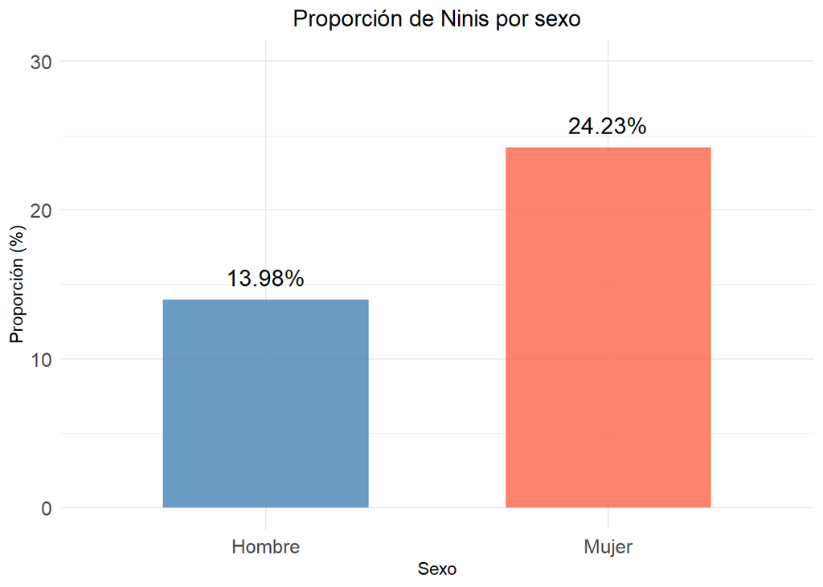

```r
ggplot(nini_sexo, aes(x = sexo, y = nini, fill = sexo)) +
  geom_bar(stat = "identity", width = 0.6, alpha = 0.8) +
  geom_text(aes(label = paste0(round(nini, 2), "%")),
            vjust = -0.8, size = 5, color = "black") +
  scale_fill_manual(values = c("steelblue", "tomato")) +
  labs(
    title = "Proporción de Ninis por sexo",
    x = "Sexo",
    y = "Proporción (%)",
    fill = "Sexo"
  ) +
  ylim(0, 30) + # Amplía el rango del eje Y
  theme_minimal() +
  theme(
    axis.text.x = element_text(size = 12),
    axis.text.y = element_text(size = 12),
    plot.title = element_text(hjust = 0.5, size = 14),
    legend.position = "none"
  )
```

## 3.4. NINI según región natural

Según región natural, en el año 2023, en la Costa (19.89%) se presentó el mayor porcentaje de población que ni estudia ni trabaja, le sigue muy cerca la Selva con 19.77% y la Sierra tiene el menor porcentaje con 17.06%.

```r
nini_region <- svyby(~nini, ~region, encuesta, svymean, deff=F, na.rm=T)
nini_region <- nini_region %>% mutate(across(where(is.numeric), ~ round(. * 100, 2)),
                                  cv = round((se/nini)*100,2))
kable(nini_region, digits = 2, row.names = FALSE, col.names = c("Region natural", "Proporción Nini", "Error estándar", "Coeficiente de variación (%)"))
```

| Region natural | Proporción Nini | Error estándar | Coeficiente de variación (%) |
| --- | --- | --- | --- |
| Costa | 19.89 | 0.59 | 2.97 |
| Selva | 19.77 | 0.76 | 3.84 |
| Sierra | 17.06 | 0.64 | 3.75 |

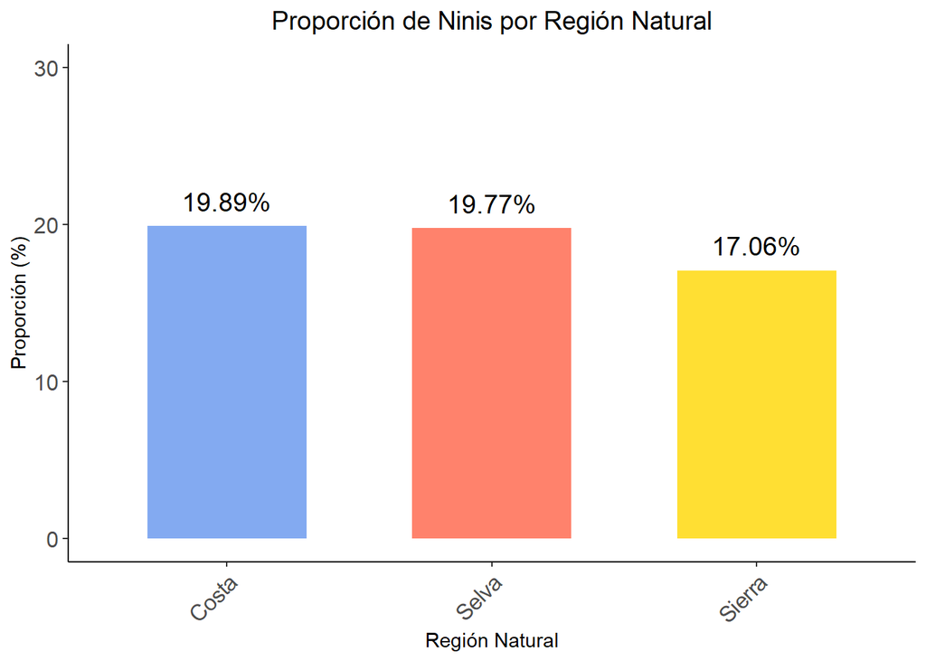

```r
# Gráfico de barras de Ninis por Region Natural
ggplot(nini_region, aes(x = region, y = nini, fill = region)) +
  geom_bar(stat = "identity", width = 0.6, alpha = 0.8) +
  geom_text(aes(label = paste0(round(nini, 2), "%")),
            vjust = -0.8, size = 5, color = "black") +
  scale_fill_manual(values = c("cornflowerblue", "tomato", "gold", "seagreen", "orchid")) +
  labs(
    title = "Proporción de Ninis por Región Natural",
    x = "Región Natural",
    y = "Proporción (%)",
    fill = "Región"
  ) +
  ylim(0, 30) +
  theme_classic() +
  theme(
    axis.text.x = element_text(size = 12, angle = 45, hjust = 1),
    axis.text.y = element_text(size = 12),
    plot.title = element_text(hjust = 0.5, size = 14),
    legend.position = "none"
  )
```

## 3.5. NINI según grupo de edad

Según grupos de edad, el grupo de menor edad (De 15 a 17 años) concentró la mayor proporción de mujeres (25.18%), que ni estudia ni trabaja, en comparación con los hombres (18.81%); lo sigue el grupo de 18 a 24 años, donde las mujeres representaron el 24.28% y los hombres el 16.52, y el grupo de 25 a 29 años, las mujeres constituyeron el 23.60% y los hombres el 7.43%.

```r
nini_edad_sexo <- svyby(~nini, ~interaction(gedad, sexo, drop = TRUE), encuesta, svymean, deff=F, na.rm=T)
colnames(nini_edad_sexo)[1] <- "GrupoEdadSexo"
nini_edad_sexo <- as.data.frame(nini_edad_sexo)
nini_edad_sexo <- nini_edad_sexo %>%
  separate(GrupoEdadSexo, into = c("Grupo de edad", "Sexo"), sep = "\\.") %>%
  arrange(`Grupo de edad`, Sexo)
nini_edad_sexo <- nini_edad_sexo %>%
  mutate(across(where(is.numeric), ~ round(. * 100, 2)),
         cv = round((se/nini)*100, 2))
# Crear una columna auxiliar que no tenga NA en la primera aparición de cada grupo de edad
nini_edad_sexo <- nini_edad_sexo %>%
  group_by(`Grupo de edad`) %>%
  mutate(Grupo_de_edad_aux = ifelse(lag(`Grupo de edad`) == `Grupo de edad`, NA, `Grupo de edad`)) %>%
  ungroup()
# Crear la tabla y agrupar celdas en la columna "Grupo de edad"
tabla_nini_edad_sexo <- kable(nini_edad_sexo %>%
  dplyr::select(`Grupo de edad`, Sexo, nini, se, cv),
  digits = 2, col.names = c("Grupo de edad", "Sexo", "Proporción Nini (%)", "Error estándar (%)", "Coeficiente de variación (%)")) %>%
  kable_styling(position = "center", full_width = FALSE, bootstrap_options = c("striped", "hover", "condensed")) %>%
  collapse_rows(columns = 1, valign = "top")

# Mostrar la tabla
tabla_nini_edad_sexo
```

| Grupo de edad | Sexo | Proporción Nini (%) | Error estándar (%) | Coeficiente de variación (%) |
| --- | --- | --- | --- | --- |
| De 15 a 17 años | Hombre | 18.81 | 1.10 | 5.85 |
|  | Mujer | 25.18 | 1.29 | 5.12 |
| De 18 a 24 años | Hombre | 16.52 | 0.76 | 4.60 |
|  | Mujer | 24.28 | 0.86 | 3.54 |
| De 25 a 29 años | Hombre | 7.43 | 0.68 | 9.15 |
|  | Mujer | 23.60 | 1.08 | 4.58 |

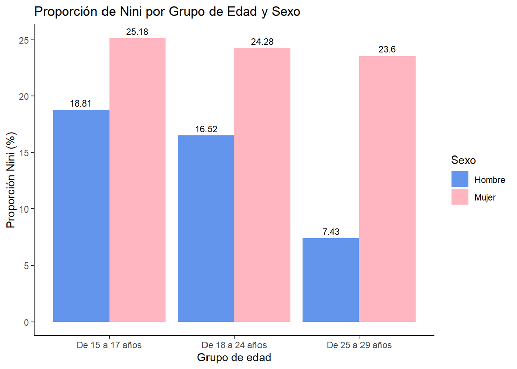

```r
ggplot(nini_edad_sexo, aes(x = `Grupo de edad`, y = `nini`, fill = Sexo)) +
  geom_bar(stat = "identity", position = "dodge") +
  geom_text(aes(label = nini), vjust = -0.5, position = position_dodge(0.9), size = 3) +
  scale_fill_manual(values = c("cornflowerblue", "lightpink")) +
  labs(title = "Proporción de Nini por Grupo de Edad y Sexo",
       x = "Grupo de edad",
       y = "Proporción Nini (%)") +
  theme_classic()
```

## 3.6. NINI según nivel educativo

```r
nini_nivel_educ <- svyby(~nini, ~nivel_educ, encuesta, svymean, deff=F, na.rm=T)
nini_nivel_educ <- nini_nivel_educ %>% mutate(across(where(is.numeric), ~ round(. * 100, 2)))
kable(nini_nivel_educ, digits = 2, col.names = c("Nivel educativo", "Proporción Nini", "Error estándar", "Coeficiente de variación (%)"))
```

[output not shown]

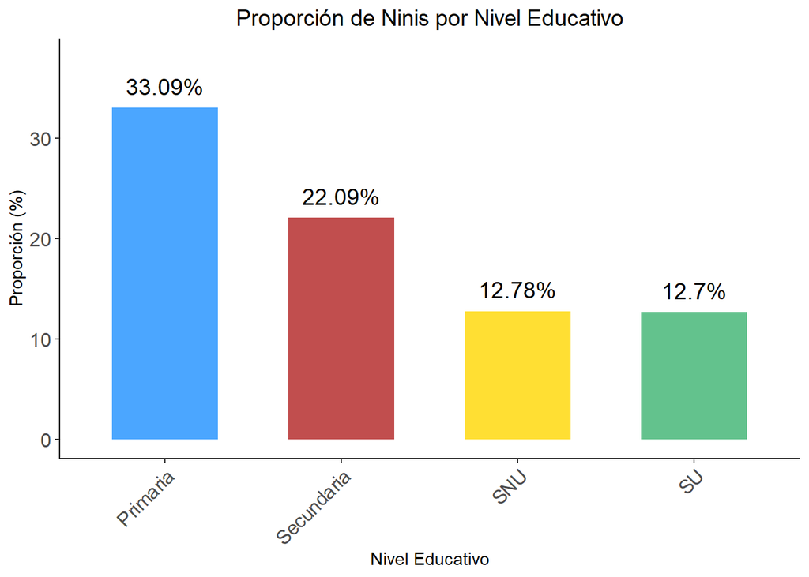

```r
# Gráfico de barras de Ninis por Nivel Educativo
ggplot(nini_nivel_educ, aes(x = nivel_educ, y = nini, fill = nivel_educ)) +
  geom_bar(stat = "identity", width = 0.6, alpha = 0.8) +
  geom_text(aes(label = paste0(round(nini, 2), "%")),
            vjust = -0.8, size = 5, color = "black") +
  scale_fill_manual(values = c("dodgerblue", "firebrick", "gold", "mediumseagreen", "mediumpurple")) +
  labs(
    title = "Proporción de Ninis por Nivel Educativo",
    x = "Nivel Educativo",
    y = "Proporción (%)",
    fill = "Nivel Educativo"
  ) +
  ylim(0, max(nini_nivel_educ$nini) + 5) +
  theme_classic() +
  theme(
    axis.text.x = element_text(size = 12, angle = 45, hjust = 1),
    axis.text.y = element_text(size = 12),
    plot.title = element_text(hjust = 0.5, size = 14),
    legend.position = "none"
  )
```

## 3.7. NINI según lengua materna

Se observa que los nini con lengua Castellano (19.43%) fue mayor que la población de nini con lengua nativa (15.75%), esta situación se hace más notoria si se disgrega por sexo. El 24.62% de las mujeres y el 14.47% de los hombres con lengua castellano, integraban los nini, existiendo una brecha del 10.15%; mientras que, en la población con lengua nativa, el 21.51% eran mujeres y el 9.72% hombres, mostrando una mayor brecha de 11.79 puntos porcentuales.

```r
# Calcular la proporción de nini por sexo y lengua materna
nini_sexo_lengua <- svyby(~nini, ~interaction(sexo, lengua, drop = TRUE), encuesta, svymean, deff=F, na.rm=T)

# Renombrar la columna combinada y convertir a data frame
colnames(nini_sexo_lengua)[1] <- "SexoLengua"
nini_sexo_lengua <- as.data.frame(nini_sexo_lengua)

# Separar la columna combinada en dos columnas y ordenar los datos
nini_sexo_lengua <- nini_sexo_lengua %>%
  separate(SexoLengua, into = c("Sexo", "Lengua materna"), sep = "\\.") %>%
  arrange(Sexo, `Lengua materna`)

# Transformaciones y cálculos adicionales
nini_sexo_lengua <- nini_sexo_lengua %>%
  mutate(Proporción_Nini = round(nini * 100, 2),
         Error_estándar = round(se * 100, 2),
         Coeficiente_variación = round((se / nini) * 100, 2))

# Calcular la proporción de nini total por lengua materna
nini_lengua <- svyby(~nini, ~lengua, encuesta, svymean, deff=F, na.rm=T)
nini_lengua <- nini_lengua %>%
  mutate(sexo = "Total",
         Proporción_Nini = round(nini * 100, 2),
         Error_estándar = round(se * 100, 2),
         Coeficiente_variación = round((se / nini) * 100, 2))

# Renombrar la columna de lengua para que coincida
colnames(nini_lengua)[1] <- "Lengua materna"

# Seleccionar y ordenar las columnas en total_lengua
nini_lengua <- nini_lengua %>%
  dplyr::select(sexo, `Lengua materna`, Proporción_Nini, Error_estándar, Coeficiente_variación)

# Combinar los datos originales con los totales
nini_sexo_lengua_total <- bind_rows(nini_sexo_lengua, nini_lengua)

# Reemplazar NA en la columna Sexo con "Total"
nini_sexo_lengua_total$Sexo[is.na(nini_sexo_lengua_total$Sexo)] <- "Total"

# Crear una columna auxiliar para identificar filas consecutivas con el mismo valor en Sexo
nini_sexo_lengua_total <- nini_sexo_lengua_total %>%
  group_by(Sexo) %>%
  mutate(Sexo_aux = ifelse(lag(Sexo) == Sexo, NA, Sexo)) %>%
  ungroup()

# Presentar la tabla con kable
tabla_nini_sexo_lengua <- kable(nini_sexo_lengua_total %>%
  dplyr::select(Sexo, `Lengua materna`, Proporción_Nini, Error_estándar, Coeficiente_variación),
  digits = 2, col.names = c("Sexo", "Lengua materna", "Proporción Nini (%)", "Error estándar (%)", "Coeficiente de variación (%)")) %>%
  kable_styling(position = "center", full_width = FALSE, bootstrap_options = c("striped", "hover", "condensed")) %>%
  collapse_rows(columns = 1, valign = "top")

# Mostrar la tabla
tabla_nini_sexo_lengua
```

| Sexo | Lengua materna | Proporción Nini (%) | Error estándar (%) | Coeficiente de variación (%) |
| --- | --- | --- | --- | --- |
| Hombre | Castellano | 14.47 | 0.54 | 3.72 |
|  | Lengua nativa | 9.72 | 1.22 | 12.59 |
| Mujer | Castellano | 24.62 | 0.66 | 2.69 |
|  | Lengua nativa | 21.51 | 1.51 | 7.01 |
| Total | Castellano | 19.43 | 0.44 | 2.24 |
|  | Lengua nativa | 15.75 | 0.97 | 6.17 |

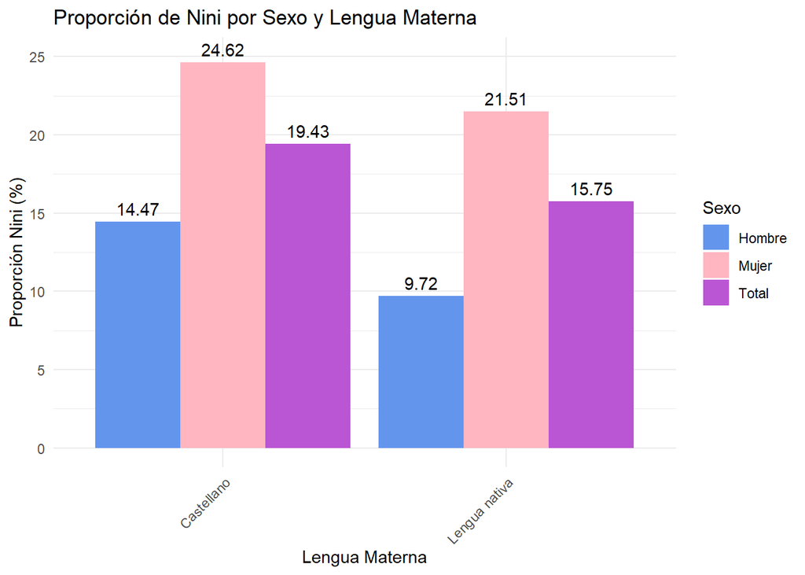

```r
ggplot(nini_sexo_lengua_total, aes(x = `Lengua materna`, y = Proporción_Nini, fill = Sexo)) +
  geom_bar(stat = "identity", position = "dodge") +
  geom_text(aes(label = Proporción_Nini), vjust = -0.5, position = position_dodge(width = 0.9)) +
  scale_fill_manual(values = c("cornflowerblue", "lightpink", "mediumorchid")) +
  labs(title = "Proporción de Nini por Sexo y Lengua Materna",
       x = "Lengua Materna",
       y = "Proporción Nini (%)") +
  ylim(0, 25) +
  theme_minimal() +
  theme(axis.text.x = element_text(angle = 45, hjust = 1))
```

# 4. Determinantes NINI

Se convierte las variables a factores

```r
jovenes$nini <- as.numeric(jovenes$nini)
jovenes$area <- as.factor(jovenes$area)
jovenes$sexo <- as.factor(jovenes$sexo)
jovenes$region <- as.factor(jovenes$region)
jovenes$gedad <- as.factor(jovenes$gedad)
jovenes$nivel_educ <- as.factor(jovenes$nivel_educ)
jovenes$lengua <- as.factor(jovenes$lengua)
```

Se estima el modelo probit

Como se observa en la siguiente tabla, los resultados del primer modelo que estimamos, indican que los jovenes que residen en zonas urbanas, que son mujeres y que tienen entre 18 a 24 años tienen mayor probabilidad de pertenecer a la población NINI. En cambio, los jovenes que viven en la sierra, que continuan sus estudios y su lengua materna es nativa tienen menor probabilidad de pertenecer a la población NINI.

```r
modelo_probit <- glm(nini ~ area + sexo + region + gedad + nivel_educ + lengua,
                     data = jovenes,
                     family = binomial(link = "probit"))
summary(modelo_probit)
```

```
##
## Call:
## glm(formula = nini ~ area + sexo + region + gedad + nivel_educ +
##     lengua, family = binomial(link = "probit"), data = jovenes)
##
## Coefficients:
##                       Estimate Std. Error z value Pr(>|z|)
## (Intercept)          -0.777055   0.047547 -16.343  < 2e-16 ***
## areaUrbano            0.165937   0.024372   6.809 9.86e-12 ***
## sexoMujer             0.429982   0.019449  22.108  < 2e-16 ***
## regionSelva          -0.033909   0.025545  -1.327 0.184370
## regionSierra         -0.082826   0.024786  -3.342 0.000833 ***
## gedadDe 18 a 24 años  0.140050   0.024953   5.613 1.99e-08 ***
## gedadDe 25 a 29 años -0.004649   0.028606  -0.163 0.870896
## nivel_educSecundaria -0.378619   0.038386  -9.863  < 2e-16 ***
## nivel_educSNU        -0.783536   0.046283 -16.929  < 2e-16 ***
## nivel_educSU         -0.798012   0.043856 -18.196  < 2e-16 ***
## lenguaLengua nativa  -0.114831   0.033052  -3.474 0.000512 ***
## ---
## Signif. codes:  0 '***' 0.001 '**' 0.01 '*' 0.05 '.' 0.1 ' ' 1
##
## (Dispersion parameter for binomial family taken to be 1)
##
##     Null deviance: 22967  on 23915  degrees of freedom
## Residual deviance: 21935  on 23905  degrees of freedom
##   (29 observations deleted due to missingness)
## AIC: 21957
##
## Number of Fisher Scoring iterations: 4
```